# Understanding How Well an Exercise is Done with Machine Learning

## Executive Summary

Wearable technology has become extremely popluar for individuals to track how much activity they are performing in their everyday life. Rarely though does a person quantify how well they perform an activity with their wearable tech. To dig into this further, the below analysis will build a predictive model from data collected during a [weightlifting exercise](http://groupware.les.inf.puc-rio.br/har) where 6 participants were asked to perform dumbell bicep curls correctly and incorrectly in 5 different ways. The model will allow us to understand if the data collected by all the sensors is enough to determine how a person is performing the exercise.

## Exploratory Analysis

First we will look at the training data set provided and understand what information has been included.

```r
library(knitr)
train <- read.csv("https://d396qusza40orc.cloudfront.net/predmachlearn/pml-training.csv")
test <- read.csv("https://d396qusza40orc.cloudfront.net/predmachlearn/pml-testing.csv")
str(train)
```

```
## 'data.frame':    19622 obs. of  160 variables:
##  $ X                       : int  1 2 3 4 5 6 7 8 9 10 ...
##  $ user_name               : Factor w/ 6 levels "adelmo","carlitos",..: 2 2 2 2 2 2 2 2 2 2 ...
##  $ raw_timestamp_part_1    : int  1323084231 1323084231 1323084231 1323084232 1323084232 1323084232 1323084232 1323084232 1323084232 1323084232 ...
##  $ raw_timestamp_part_2    : int  788290 808298 820366 120339 196328 304277 368296 440390 484323 484434 ...
##  $ cvtd_timestamp          : Factor w/ 20 levels "02/12/2011 13:32",..: 9 9 9 9 9 9 9 9 9 9 ...
##  $ new_window              : Factor w/ 2 levels "no","yes": 1 1 1 1 1 1 1 1 1 1 ...
##  $ num_window              : int  11 11 11 12 12 12 12 12 12 12 ...
##  $ roll_belt               : num  1.41 1.41 1.42 1.48 1.48 1.45 1.42 1.42 1.43 1.45 ...
##  $ pitch_belt              : num  8.07 8.07 8.07 8.05 8.07 8.06 8.09 8.13 8.16 8.17 ...
##  $ yaw_belt                : num  -94.4 -94.4 -94.4 -94.4 -94.4 -94.4 -94.4 -94.4 -94.4 -94.4 ...
##  $ total_accel_belt        : int  3 3 3 3 3 3 3 3 3 3 ...
##  $ kurtosis_roll_belt      : Factor w/ 397 levels "","-0.016850",..: 1 1 1 1 1 1 1 1 1 1 ...
##  $ kurtosis_picth_belt     : Factor w/ 317 levels "","-0.021887",..: 1 1 1 1 1 1 1 1 1 1 ...
##  $ kurtosis_yaw_belt       : Factor w/ 2 levels "","#DIV/0!": 1 1 1 1 1 1 1 1 1 1 ...
```

[output cut: 86 more lines]

There are a total of 19622 observtions and 160 variables in the training data set. The first 7 columns include time stamps, participant name and some other pieces of information that are not important for creating a model. These columns will be removed before any modelling is done.

There are also a number of columns that have NA values in them which will not work with the caret package. On the website where this data is pulled from there is a paper called “Qualitative Activity Recognition of Weight Lifting Exercises” that explains the data set in detail. In section 5.1 it explains that a feature selection algorithm was run on the raw data and the columns with amplitude, min, max, avg, stddev, var, kurtosis or skewness in the name, also the ones with NA values, are calculations based off the raw data. In this analysis we are concerned only with the raw data collected so these columns will also be removed.

```r
trainSub <- train[, !grepl("amplitude|min|max|avg|stddev|var|kurtosis|skewness", names(train))]
trainSub <- trainSub[,8:60]
```

The next thing to look at it is whether the data will require any preprocessing.

```r
means <- colMeans(trainSub[,-53])
sd <- apply(trainSub, 2, sd)
```

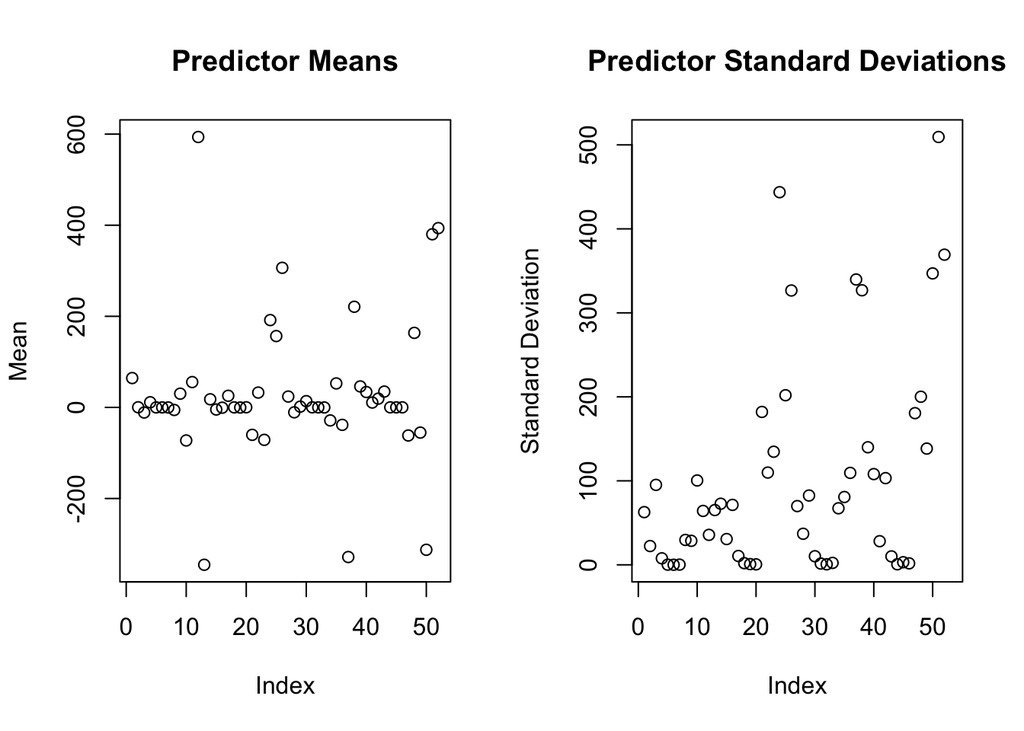

```r
par(mfrow=c(1,2))
plot(means, main="Predictor Means", ylab="Mean")
plot(sd, main="Predictor Standard Deviations", ylab="Standard Deviation")
```

The above graphs show that there are a number of predictors in the data set that have a large mean and standard deviation. This means some of the data is skewed and highly variable which can trick the model when it is created. To accomodate for this the data will be centered and scaled prior to any model fitting. The next check is to see if any of the variables are highly correlated with each other.

```r
M <- abs(cor(trainSub[,-53]))
diag(M) <- 0
which(M > 0.8, arr.ind=T)
```

```
##                  row col
## yaw_belt           3   1
## total_accel_belt   4   1
## accel_belt_y       9   1
## accel_belt_z      10   1
## accel_belt_x       8   2
## magnet_belt_x     11   2
## roll_belt          1   3
## roll_belt          1   4
## accel_belt_y       9   4
## accel_belt_z      10   4
## pitch_belt         2   8
## magnet_belt_x     11   8
## roll_belt          1   9
## total_accel_belt   4   9
## accel_belt_z      10   9
## roll_belt          1  10
## total_accel_belt   4  10
## accel_belt_y       9  10
## pitch_belt         2  11
## accel_belt_x       8  11
## gyros_arm_y       19  18
## gyros_arm_x       18  19
## magnet_arm_x      24  21
## accel_arm_x       21  24
## magnet_arm_z      26  25
## magnet_arm_y      25  26
## accel_dumbbell_x  34  28
## accel_dumbbell_z  36  29
## gyros_dumbbell_z  33  31
## gyros_forearm_z   46  31
## gyros_dumbbell_x  31  33
## gyros_forearm_z   46  33
## pitch_dumbbell    28  34
## yaw_dumbbell      29  36
## gyros_forearm_z   46  45
## gyros_dumbbell_x  31  46
## gyros_dumbbell_z  33  46
## gyros_forearm_y   45  46
```

The above matrix indicates that there are a lot of variables in the data set that have strong correlations with each other. This is not surprising as the same measurements were taken just in different directions (x, y and z plane). To account for this, principle component analysis will be applied to the data when creating the model.

## Model Fitting

Now that the data is understood, we will start with creating a random forest model in caret with centering, scalaing and PCA preprocessing. The data will as undergo a 10 k-fold cross validation as well so the out of sample error rate can be understood.

```r
library(caret)
set.seed(100)
fitControl <- trainControl(method = "cv", number = 10)
fit <- train(classe ~., data = trainSub, preProcess = c("center", "scale", "pca"), method="rf", trControl=fitControl)
fit
```

```
## Random Forest
##
## 19622 samples
##    52 predictor
##     5 classes: 'A', 'B', 'C', 'D', 'E'
##
## Pre-processing: centered (52), scaled (52), principal component
##  signal extraction (52)
## Resampling: Cross-Validated (10 fold)
## Summary of sample sizes: 17659, 17662, 17659, 17660, 17660, 17662, ...
## Resampling results across tuning parameters:
##
##   mtry  Accuracy   Kappa
##    2    0.9824693  0.9778235
##   27    0.9743661  0.9675741
##   52    0.9737034  0.9667375
##
## Accuracy was used to select the optimal model using  the largest value.
## The final value used for the model was mtry = 2.
```

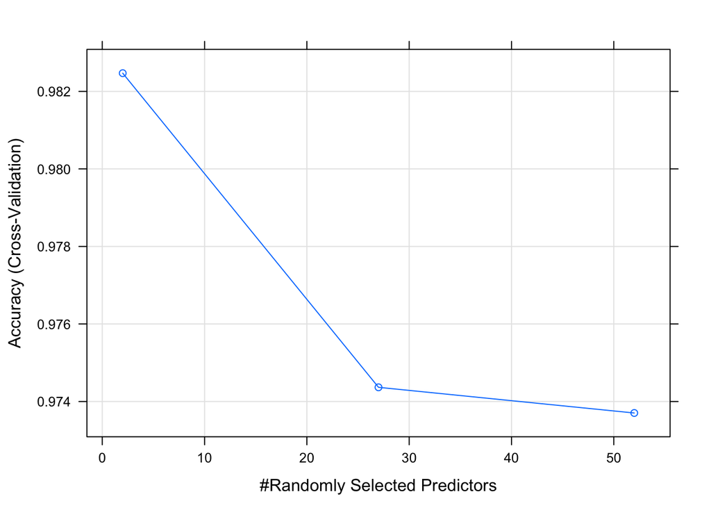

```r
plot(fit)
```

The above plot of the model shows that we can get the highest accuracy (over 98%) with 2 variables at each split of the tree.

Lastly, looking at the Final Model of fit, we can see that the out of sample error rate is 1.61%.

```r
fit$finalModel
```

```
##
## Call:
##  randomForest(x = x, y = y, mtry = param$mtry)
##                Type of random forest: classification
##                      Number of trees: 500
## No. of variables tried at each split: 2
##
##         OOB estimate of  error rate: 1.61%
## Confusion matrix:
##      A    B    C    D    E class.error
## A 5553    6   14    4    3  0.00483871
## B   49 3720   26    0    2  0.02027917
## C    3   36 3357   23    3  0.01899474
## D    2    2   97 3110    5  0.03296020
## E    0    9   18   14 3566  0.01136679
```

With this low out of sample error rate and high accuracy we can conclude that the random forest model generated in the above model fitting provides a good estimate of the data. This is the final model that will be used for prediction of future test cases.

## Prediction of Test Cases

With the final model developed above and the test data set provided in the assignment, the same data tidying will be applied as was done with the training set and it will then be analyzed with the model to estimate the classe.

```r
testSub <- test[, !grepl("amplitude|min|max|avg|stddev|var|kurtosis|skewness", names(test))]
testSub <- testSub[,8:60]

pred <- predict(fit, newdata=testSub)

testSub$classe <- pred
```

The classes for the test data are as follows.

```r
pred
```

```
##  [1] B A A A A E D B A A B C B A E E A B B B
## Levels: A B C D E
```